# Module Nine Project

For the module nine project you are required to produce coding samples in accordance with the requirements in the project guidelines and rubric. This Notebook has been pre-created as a shell for your project submission.

Once your code is complete, you will download this notebook as an HTML file by clicking **File**, then **Download As**, then **HTML (.html)** from the Jupyter menu bar. Validate that your code and outputs are rendered in the html file before submission.

*Missing Blocks:* Ensure that you have clicked **Run** for all blocks before downloading as an HTML file or the block may be missing from your submission.

### Data Source Information

Below are some example reputable data sources that you can use to collect your minimum of two data sets from:

- https://datasetsearch.research.google.com/
- https://www.kaggle.com/datasets
- https://data.gov/
- https://www.census.gov/data.html
- https://www.bls.gov/data/
- https://databank.worldbank.org/databases
- https://www.ncei.noaa.gov/access/search/index
- https://www.epa.gov/data
- https://www.pewresearch.org/tools-and-datasets/
- https://www.who.int/data/
- https://dataverse.harvard.edu/
- https://search.cdc.gov/search/?query=dataset&dpage=1
- https://data.fivethirtyeight.com/
- https://www.gdeltproject.org/data.html
- https://datahub.io/collections

***Note: this list is not all inclusive, if you have a reputable data set that you have collected, or would like to use, please ensure to upload the data. All data sets will need to be documented in your submission as to the source through the creation of a citation.***

*To Begin:* replace each **data_file_#** entry sample data path with the path to your selected data sets.

You are welcome to use more than two data sets, create an entry for each as applicable for each data set. Ensure that you create comments that provide citations for the data sets you have selected for use. When working through your submission, keep in mind that you will need to have choosen two separate groups of stakeholders to create your final visualizations.

```python
#     McAuley, J. (2024). Amazon Product Data: Books.
#     University of California San Diego.
#     Retrieved from https://jmcauley.ucsd.edu/data/amazon_v2/categoryFilesSmall/Books.csv
data_file_1 = "data/Books_small.csv"
#     McAuley, J. (n.d.). Amazon Product Data: Kindle Store.
#     University of California San Diego.
#     Retrieved from https://jmcauley.ucsd.edu/data/amazon_v2/categoryFilesSmall/Kindle_Store.csv
data_file_2 = "data/Kindle_Store_small.csv"
```

### Data Sources

- McAuley, J. (2024). Amazon Product Data: Books. UC San Diego.
- McAuley, J. (n.d.). Amazon Product Data: Kindle Store. UC San Diego.

## Installing Required Packages

If you have additional packages that you would like to use or install, add them to the **requirements.txt** file then run the next two blocks.

```python
!pip install --upgrade pip
```

```python
!pip install -r requirements.txt
```

## Import the Required Packages

```python
import pandas as pd
import numpy as np
import matplotlib.pyplot as plt
import seaborn as sns
import os


# Optional formatting to give nicer, cleaner, plots.
sns.set(style = "whitegrid")

#To ensure that the visualizations can be output.
os.makedirs("data_output", exist_ok = True)
```

## Loading the Data

Create entries to load your data for your submission.

```python
# Defines the proper column names for the Amazon review dataset.
column_names = ["asin", "reviewerID", "rating", "unixReviewTime"]

# Loads the datasets. These files currently have no header row.
books_df = pd.read_csv(
    data_file_1,
    names = column_names,
    header = None,
    low_memory = False
)

kindle_df = pd.read_csv(
    data_file_2,
    names = column_names,
    header = None,
    low_memory = False
)

# Displays the first few rows to confirm that loading was successful.
books_df.head(), kindle_df.head()

# Inspects the structure of each dataset.
books_df.info()
kindle_df.info()
```

```
<class 'pandas.core.frame.DataFrame'>
RangeIndex: 1048576 entries, 0 to 1048575
Data columns (total 4 columns):
 #   Column          Non-Null Count  Dtype
---  ------          --------------  -----
 0   asin            5000 non-null   object
 1   reviewerID      5000 non-null   object
 2   rating          5000 non-null   float64
 3   unixReviewTime  5000 non-null   float64
dtypes: float64(2), object(2)
memory usage: 32.0+ MB
<class 'pandas.core.frame.DataFrame'>
RangeIndex: 5000 entries, 0 to 4999
Data columns (total 4 columns):
 #   Column          Non-Null Count  Dtype
---  ------          --------------  -----
 0   asin            5000 non-null   object
 1   reviewerID      5000 non-null   object
 2   rating          5000 non-null   int64
 3   unixReviewTime  5000 non-null   int64
dtypes: int64(2), object(2)
memory usage: 156.4+ KB
```

## Examining the Data

Create entries to conduct exploratory data analysis to identify key data points to include relevant data from your two data sets while evaluating the quality of your choosen data.

```python
# ============================
# EXAMINING THE DATA (EDA)
# ============================

# 1. This is the basic overview of dataset shapes.
print("Books Dataset Shape:", books_df.shape)
print("Kindle Dataset Shape:", kindle_df.shape)

# 2. This previews the first few rows.
display(books_df.head())
display(kindle_df.head())

# 3. This shows the data types and non-null counts.
print("\n--- Books Dataset Info ---")
books_df.info()

print("\n--- Kindle Dataset Info ---")
kindle_df.info()

# 4. This checks for missing values within the datasets.
print("\nMissing values in Books dataset:")
print(books_df.isnull().sum())

print("\nMissing values in Kindle dataset:")
print(kindle_df.isnull().sum())

# 5. This is the descriprive statistics for the numeric columns.
print("\n--- Books Dataset Description ---")
display(books_df.describe())

print("\n--- Kindle Dataset Description ---")
display(kindle_df.describe())

# 6. This checks for duplicate rows.
print("Duplicate rows in Books:", books_df.duplicated().sum())
print("Duplicate rows in Kindle:", kindle_df.duplicated().sum())

# 7. This is the unique counts for key identifiers.
print("\nUnique ASINs in Books:", books_df['asin'].nunique())
print("Unique ASINs in Kindle:", kindle_df['asin'].nunique())

print("\nUnique reviewers in Books:", books_df['reviewerID'].nunique())
print("Unique reviewers in Kindle:", kindle_df['reviewerID'].nunique())

# 8. This converts timestamps to readable dates.
books_df['reviewTime'] = pd.to_datetime(books_df['unixReviewTime'], unit = 's')
kindle_df['reviewTime'] = pd.to_datetime(kindle_df['unixReviewTime'], unit = 's')

print("\nConverted timestamps. Preview with new date column:")
display(books_df.head())
display(kindle_df.head())
```

```
Books Dataset Shape: (1048576, 4)
Kindle Dataset Shape: (5000, 4)
```

|  | asin | reviewerID | rating | unixReviewTime |
| --- | --- | --- | --- | --- |
| 0 | 0001713353 | A1C6M8LCIX4M6M | 5.0 | 1.123805e+09 |
| 1 | 0001713353 | A1REUF3A1YCPHM | 5.0 | 1.112141e+09 |
| 2 | 0001713353 | A1YRBRK2XM5D5 | 5.0 | 1.081037e+09 |
| 3 | 0001713353 | A1V8ZR5P78P4ZU | 5.0 | 1.077322e+09 |
| 4 | 0001713353 | A2ZB06582NXCIV | 5.0 | 1.475453e+09 |

|  | asin | reviewerID | rating | unixReviewTime |
| --- | --- | --- | --- | --- |
| 0 | 1423600150 | A27UD5HYAKBL97 | 4 | 1356739200 |
| 1 | 1423600150 | A8P5DK8LLOYGH | 5 | 1330992000 |
| 2 | 1423600150 | A3OM9W7DXSUIIY | 5 | 1250035200 |
| 3 | 1423600150 | A3DPAR2PWB9BT8 | 3 | 1162512000 |
| 4 | 1423600150 | A2ONTBSAX7GIOV | 5 | 1144713600 |

```
--- Books Dataset Info ---
<class 'pandas.core.frame.DataFrame'>
RangeIndex: 1048576 entries, 0 to 1048575
Data columns (total 4 columns):
 #   Column          Non-Null Count  Dtype
---  ------          --------------  -----
 0   asin            5000 non-null   object
 1   reviewerID      5000 non-null   object
 2   rating          5000 non-null   float64
 3   unixReviewTime  5000 non-null   float64
dtypes: float64(2), object(2)
memory usage: 32.0+ MB

--- Kindle Dataset Info ---
<class 'pandas.core.frame.DataFrame'>
RangeIndex: 5000 entries, 0 to 4999
Data columns (total 4 columns):
 #   Column          Non-Null Count  Dtype
---  ------          --------------  -----
 0   asin            5000 non-null   object
 1   reviewerID      5000 non-null   object
 2   rating          5000 non-null   int64
 3   unixReviewTime  5000 non-null   int64
dtypes: int64(2), object(2)
memory usage: 156.4+ KB

Missing values in Books dataset:
asin              1043576
reviewerID        1043576
rating            1043576
unixReviewTime    1043576
dtype: int64

Missing values in Kindle dataset:
asin              0
reviewerID        0
rating            0
unixReviewTime    0
dtype: int64

--- Books Dataset Description ---
```

|  | rating | unixReviewTime |
| --- | --- | --- |
| count | 5000.000000 | 5.000000e+03 |
| mean | 4.514000 | 1.381324e+09 |
| std | 1.048439 | 1.263860e+08 |
| min | 1.000000 | 8.761824e+08 |
| 25% | 5.000000 | 1.360454e+09 |
| 50% | 5.000000 | 1.419336e+09 |
| 75% | 5.000000 | 1.462342e+09 |
| max | 5.000000 | 1.523578e+09 |

```
--- Kindle Dataset Description ---
```

|  | rating | unixReviewTime |
| --- | --- | --- |
| count | 5000.000000 | 5.000000e+03 |
| mean | 4.038400 | 1.332515e+09 |
| std | 1.295709 | 1.563664e+08 |
| min | 1.000000 | 8.774784e+08 |
| 25% | 3.000000 | 1.228219e+09 |
| 50% | 5.000000 | 1.391688e+09 |
| 75% | 5.000000 | 1.446682e+09 |
| max | 5.000000 | 1.525824e+09 |

```
Duplicate rows in Books: 1043586
Duplicate rows in Kindle: 17

Unique ASINs in Books: 40
Unique ASINs in Kindle: 49

Unique reviewers in Books: 4885
Unique reviewers in Kindle: 4909

Converted timestamps. Preview with new date column:
```

|  | asin | reviewerID | rating | unixReviewTime | reviewTime |
| --- | --- | --- | --- | --- | --- |
| 0 | 0001713353 | A1C6M8LCIX4M6M | 5.0 | 1.123805e+09 | 2005-08-12 |
| 1 | 0001713353 | A1REUF3A1YCPHM | 5.0 | 1.112141e+09 | 2005-03-30 |
| 2 | 0001713353 | A1YRBRK2XM5D5 | 5.0 | 1.081037e+09 | 2004-04-04 |
| 3 | 0001713353 | A1V8ZR5P78P4ZU | 5.0 | 1.077322e+09 | 2004-02-21 |
| 4 | 0001713353 | A2ZB06582NXCIV | 5.0 | 1.475453e+09 | 2016-10-03 |

|  | asin | reviewerID | rating | unixReviewTime | reviewTime |
| --- | --- | --- | --- | --- | --- |
| 0 | 1423600150 | A27UD5HYAKBL97 | 4 | 1356739200 | 2012-12-29 |
| 1 | 1423600150 | A8P5DK8LLOYGH | 5 | 1330992000 | 2012-03-06 |
| 2 | 1423600150 | A3OM9W7DXSUIIY | 5 | 1250035200 | 2009-08-12 |
| 3 | 1423600150 | A3DPAR2PWB9BT8 | 3 | 1162512000 | 2006-11-03 |
| 4 | 1423600150 | A2ONTBSAX7GIOV | 5 | 1144713600 | 2006-04-11 |

## Data Preprocessing Techniques

Create entries to clean and blend your data sets as applicable consolidating the two or more data sets into a single collection for inclusion into your visualizations.

```python
# ============================
# DATA PREPROCESSING
# ============================

# 1. This removes duplicate rows.
books_df = books_df.drop_duplicates()
kindle_df = kindle_df.drop_duplicates()

# 2. This removes rows with missing essential values.
books_df = books_df.dropna(subset = ["asin", "rating"])
kindle_df = kindle_df.dropna(subset = ["asin", "rating"])

# 3. This filters out invalid ratings. This is due to Amazon ratings needing to be 1-5.
books_df = books_df[(books_df["rating"] >= 1) & (books_df["rating"] <= 5)]
kindle_df = kindle_df[(kindle_df["rating"] >= 1) & (kindle_df["rating"] <= 5)]

# 4. This extracts year and month from reviewTime for time‑based analysis.
books_df["year"] = books_df["reviewTime"].dt.year
kindle_df["year"] = kindle_df["reviewTime"].dt.year

books_df["month"] = books_df["reviewTime"].dt.to_period("M")
kindle_df["month"] = kindle_df["reviewTime"].dt.to_period("M")

# ============================
# BLENDING THE DATASETS
# ============================

# This adds a source label to each dataset.
books_df["source"] = "Books"
kindle_df["source"] = "Kindle"

# This combines into a single dataset.
combined_df = pd.concat([books_df, kindle_df], ignore_index = True)

# This is the preview of the combined dataset for verification.
combined_df.head()
```

|  | asin | reviewerID | rating | unixReviewTime | reviewTime | year | month | source |
| --- | --- | --- | --- | --- | --- | --- | --- | --- |
| 0 | 0001713353 | A1C6M8LCIX4M6M | 5.0 | 1.123805e+09 | 2005-08-12 | 2005 | 2005-08 | Books |
| 1 | 0001713353 | A1REUF3A1YCPHM | 5.0 | 1.112141e+09 | 2005-03-30 | 2005 | 2005-03 | Books |
| 2 | 0001713353 | A1YRBRK2XM5D5 | 5.0 | 1.081037e+09 | 2004-04-04 | 2004 | 2004-04 | Books |
| 3 | 0001713353 | A1V8ZR5P78P4ZU | 5.0 | 1.077322e+09 | 2004-02-21 | 2004 | 2004-02 | Books |
| 4 | 0001713353 | A2ZB06582NXCIV | 5.0 | 1.475453e+09 | 2016-10-03 | 2016 | 2016-10 | Books |

## Data Visualizations

Create entries to visualize your data using appropriate visualization types to reveal key trends within the data collection. Integrate multiple data attributes into visualizations using appropriate techniques to derive key insights from your visualizations. In your data visualizations, you will use multi-level data modeling practices to refine your visualizations. Your visualizations should include a high-level visualization that provides a broad overview of the data for one of your two stakeholders, as well as a detailed, insight-focused visualization that highlights the key findings for the other of your two stakeholders.

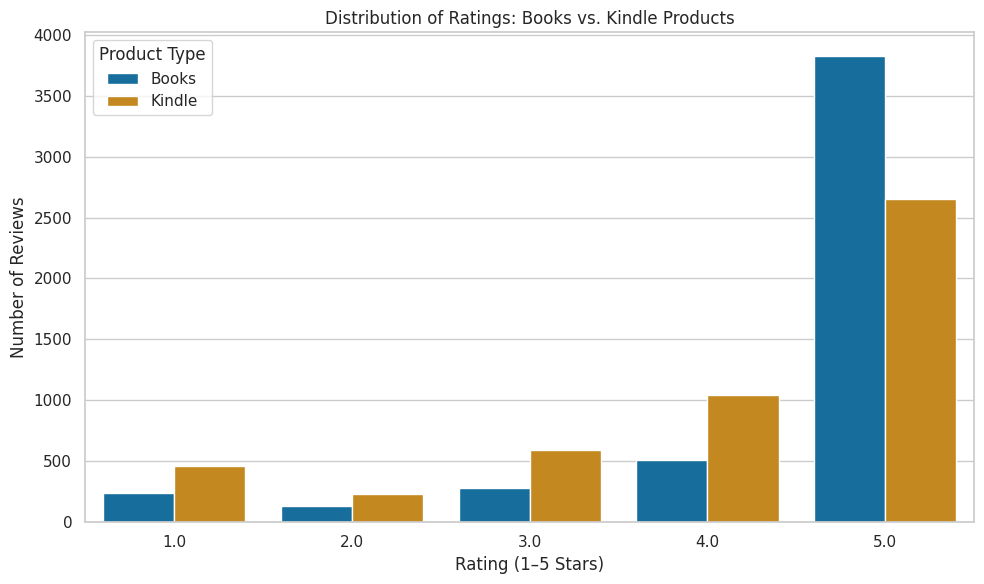

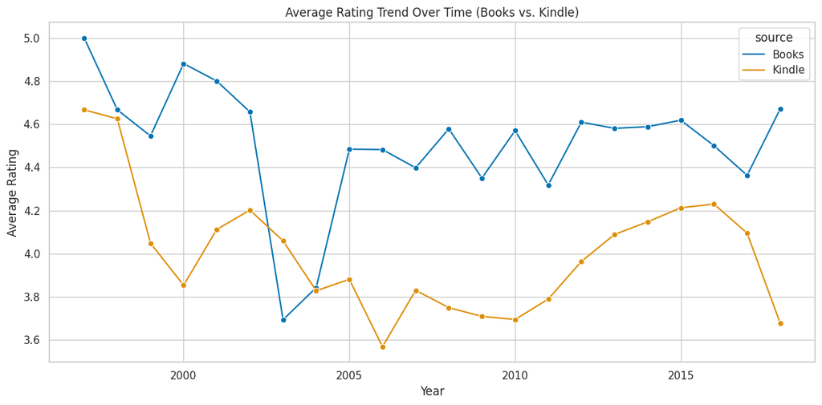

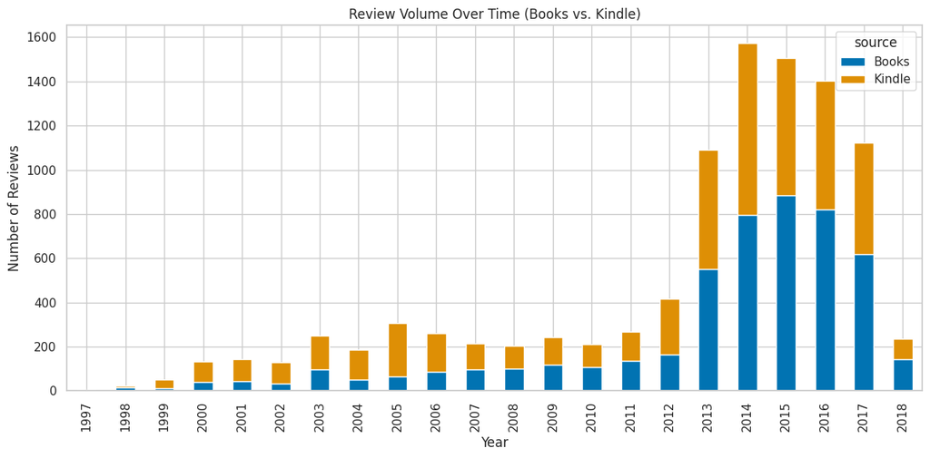

```python
# ============================
# HIGH-LEVEL VISUALIZATION
# ============================

plt.figure(figsize = (10, 6))
sns.countplot(
    data = combined_df,
    x = "rating",
    hue = "source",
    palette = "colorblind"
)

plt.title("Distribution of Ratings: Books vs. Kindle Products")
plt.xlabel("Rating (1–5 Stars)")
plt.ylabel("Number of Reviews")
plt.legend(title = "Product Type")
plt.tight_layout()

# This saves the figure.
plt.savefig("data_output/high_level_rating_distribution.png", dpi = 300)

plt.show()


# ============================
# INSIGHT-FOCUSED VISUALIZATION
# ============================

# Creates a year column.
combined_df["year"] = combined_df["reviewTime"].dt.year

# Computes the yearly average ratings.
yearly_trends = (
    combined_df.groupby(["year", "source"])["rating"]
    .mean()
    .reset_index()
)

plt.figure(figsize = (12, 6))
sns.lineplot(
    data = yearly_trends,
    x = "year",
    y = "rating",
    hue = "source",
    marker = "o",
    palette = "colorblind"
)

plt.title("Average Rating Trend Over Time (Books vs. Kindle)")
plt.xlabel("Year")
plt.ylabel("Average Rating")
plt.tight_layout()

# Saves the figure.
plt.savefig("data_output/yearly_rating_trend.png", dpi = 300)

plt.show()


# ============================
# ADDITIONAL INSIGHT VISUALIZATION
# ============================

# Computes the yearly review counts.
yearly_counts = (
    combined_df.groupby(["year", "source"])["rating"]
    .count()
    .reset_index()
    .rename(columns = {"rating": "review_count"})
)

# This is a pivot for a stacked bar chart.
yearly_pivot = yearly_counts.pivot(
    index = "year",
    columns = "source",
    values = "review_count"
).fillna(0)

plt.figure(figsize = (12, 6))
yearly_pivot.plot(
    kind = "bar",
    stacked = True,
    color = sns.color_palette("colorblind"),
    figsize = (12, 6)
)

plt.title("Review Volume Over Time (Books vs. Kindle)")
plt.xlabel("Year")
plt.ylabel("Number of Reviews")
plt.tight_layout()

# Saves the figure.
plt.savefig("data_output/yearly_review_volume_stacked.png", dpi = 300)

plt.show()
```